## Grunnleggende bakgrunnkunnskaper

### Stabiliseringsmål for en åpen økonomi

- Intern balanse (lukke produksjonsgapet):

$$(Y-\overline{Y})=0$$

- Ekstern balanse (rimelig nivå på utenlandsgjelden - gjelden skal kunne betjenes uten problemer)

### Tre fundamentale endringer fra en lukket økonomi

#### (1) Handel med utlandet

$$AE \equiv C+I+G+NX$$
$NX$ er nå inkludert i definisjonen for aggregert etterspørsel

NX er definert som eksport $(EX)$ minus import $(R\cdot IM)$ målt i enheter av det innenlandske godet:

$$NX=EX−R\cdot IM \text{ }$$
Realvalutakursen $R=\frac{E\cdot P^{*}}{P}$ (prisforholdet mellom utenlandske og innenlandske goder målt i enheter av det innenlandske gode) sørger her for at alt blir målt i enheter av det innenlandske godet.

#### (2) Fast eller flytende kurs

Renteparitetsbetingelsen

$$(1+i_{t+1})=(1+i_{t+1}^{*})\frac{E_{t+1}^{e}}{E_{t}}$$
Likevektsbetingelse som forteller oss at den forventede avkastningen er lik mellom å investere i inn- og utland.

Her er $i_{t+1}$ innelandsk avkastning, $i_{t+1}^{*}$ utenlands avkastning, $E_{t}$ er (nominelle) prisen i dag per énhet av utenlandsk valuta og $E_{t+1}^{e}$ den forventede valutakursen én periode frem i tid.

#### (3) Utenriksregnskapet (BoP)

$$BP = CA + CU + OR=0$$

$CU=\text{Driftsregnskapet}$.

Består av nettoeksport (NX), pluss nettofinansinntekter(aksjer og obligasjoner) og nettoverføringer

$CA=\text{Kapitalregnskapet}$

Nettoendringer i fordringer og gjeld ovenfor utlandet

$OR=\text{Endringer i sentralbankens valutareserver}$

Vil øke (reduseres) dersom fastkursprisen er svakere (sterkere) enn det som markedet er villig til å betale

## Mundell-Fleming modellen

### Adferdsligninger

#### Husholdninger og bedrifter

Husholdningene import ($IM$) av utenlandske goder er gitt ved

$$IM= -m_{1}R + m_{2}Y$$

Bedriftenes eksport ($EX$) av innenlandske goder er gitt ved

$$EX=x_{1}R + x_{2}Y^{*}$$

Ved å sett inn for uttrykkene ovenfor, kan vi skrive nettoeksporten som

Legger til grunn i dette kurset at priseffekten dominerer innteksteffekten ([Marshall-Lerner betingelsen](https://en.wikipedia.org/wiki/Marshall%E2%80%93Lerner_condition) ):

$$\frac{\Delta NX}{\Delta R}= \underset{priseffekt}{x_{1}} - \underset{inntektseffekt}{IM} + \underset{priseffekt}{m_{1}R} > 0 \text{ (i praksis vil dette ta litt tid)}$$

#### Offentlige myndigheter (instruering) og sentralbanken (implementering)

Myndighetene kan velge mellom fast eller flytende kurs:

- Fast
  $$i =i^{*} + rp$$

Anser markedsaktørene faskursregimet som troverdig, har vi at $E=E^{e} \Rightarrow rp=0$

- Flytende

$$E=\frac{(1+i^{*})}{(1+i)}E^{e}$$

## Mundell-Fleming modellen under fast kurs

Viser den samtidige likevekten i gode-, penge- og valutakursmarkedet under fast kurs

### Godemarkedet

$$Y = \frac{1}{1-c(1-t) + R\cdot m_{2}} \left [ \overline{C} + \overline{I} - b\cdot \overline{i} + \overline{G} + EX + R^{2}\cdot m_{1} \right]$$

### Pengemarkedet

$$kY -hi = \overline{M}/P$$

### Valutakursmarkedet

$$i =i^{*} + rp$$

**Formelt**

$$i =i^{*} + rp \text{ BoP-kurven}$$

**Grafisk**

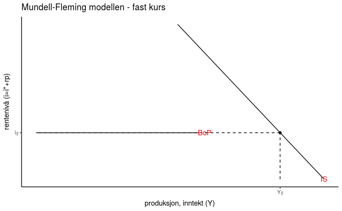

### Komparativ statikk (skiftanalyse)

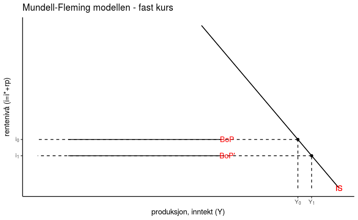

### Stabiliseringspolitikk (G og T)

Eks. reduksjon i offentlig utgifter ($\overline{G}<0$)

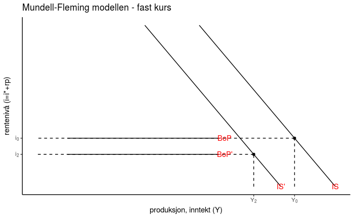

Merk: Under fast kurs er renta bundet til å holde fastkursen stabil, det gjør at finanspolitikk (endring i offentlige utgifter og skatter) står igjen som de eneste virkemidelene som kan stabillisere konjunkturbevegelsene.

## Mundell-Fleming modellen under flytende kurs

Viser den samtidige likevekten i gode-, penge- og valutakursmarkedet under flytende kurs.

### Pengemarkedet

$$kY -hi = \overline{M}/P$$

### BP

$$E=\frac{(1+i^{*})}{(1+i)}E^{e}$$

**Formelt**

**Grafisk**

Viser den samtidige likevekten i gode-, penge- og valutakursmarkedet (flytende kurs)

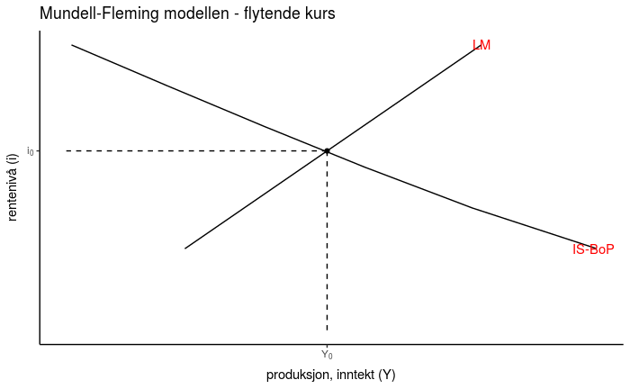

### Komparativ statikk (skiftanalyse)

[output not shown]

[figure not shown]

[figure not shown]

### Stabiliseringspolitikk (M/(i), G og T)

Eks. reduksjon i pengmengden ($\overline{M}<0$)